# CUNY Bridge: Data Science Math - Final Project

### Descriptive and Inferential Statistics.

```r
#Provide univariate descriptive statistics and appropriate plots.
summary(df)
```

```
       x               y
 Min.   : 34.0   Min.   :  79.0
 1st Qu.: 77.0   1st Qu.: 393.0
 Median :128.0   Median : 809.0
 Mean   :129.3   Mean   : 789.7
 3rd Qu.:165.0   3rd Qu.:1043.0
 Max.   :575.0   Max.   :3904.0
```

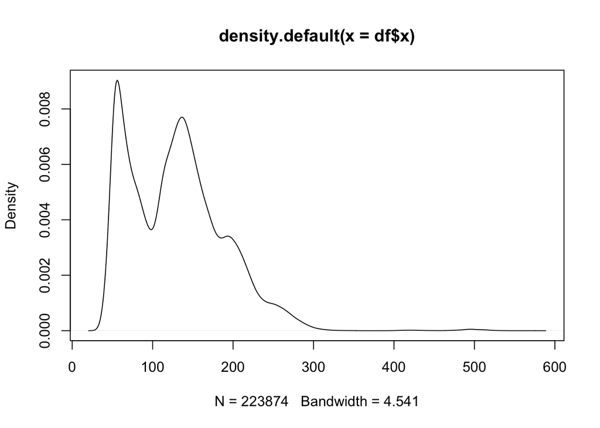

```r
plot(density(df$x))
```

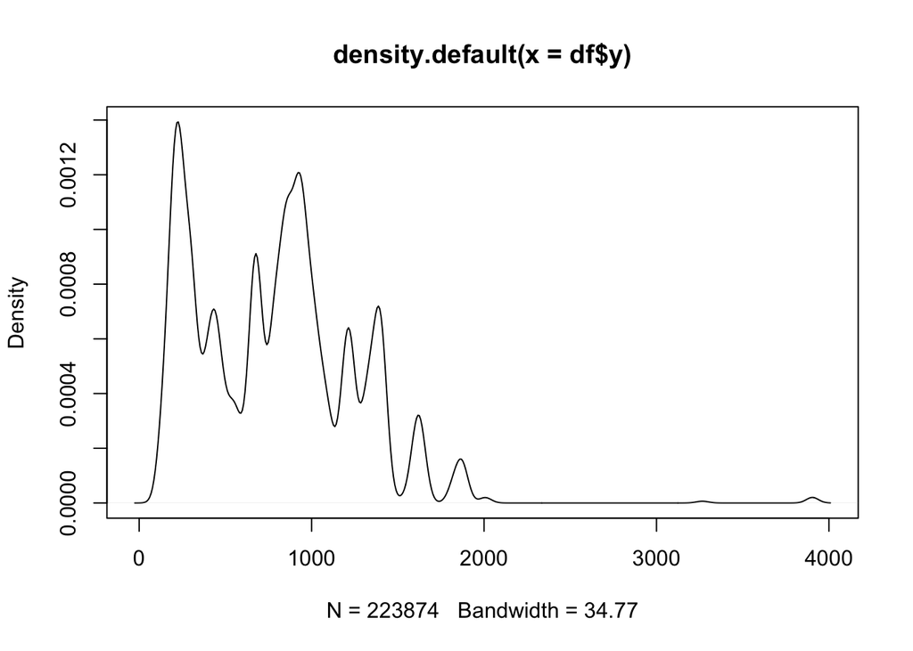

```r
plot(density(df$y))
```

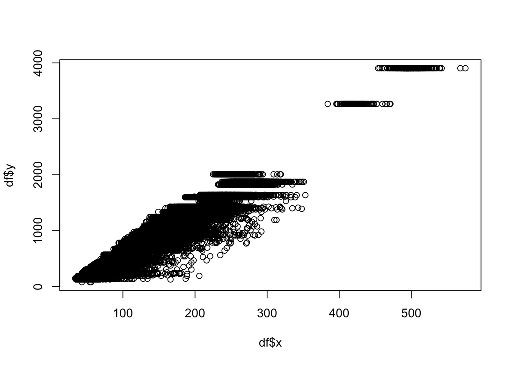

```r
#Provide a scatterplot of the two variables.
plot(df$x, df$y)
```

```r
#Provide a 95% CI for the difference in the mean of the variables.
t.test(df$y, df$x)
```

```
    Welch Two Sample t-test

data:  df$y and df$x
t = 682.5907, df = 231508.6, p-value < 2.2e-16
alternative hypothesis: true difference in means is not equal to 0
95 percent confidence interval:
 658.5146 662.3071
sample estimates:
mean of x mean of y
 789.7346  129.3237
```

```r
#Derive a correlation matrix for two of the quantitative variables you selected.
CorMatrix <- cor(df)
CorMatrix
```

```
          x         y
x 1.0000000 0.9743551
y 0.9743551 1.0000000
```

```r
#Test the hypothesis that the correlation between these variables is 0 and provide a 99% confidence interval.  Discuss the meaning of your analysis.
cor.test(df$x, df$y, conf.level=0.99)
```

```
    Pearson's product-moment correlation

data:  df$x and df$y
t = 2048.821, df = 223872, p-value < 2.2e-16
alternative hypothesis: true correlation is not equal to 0
99 percent confidence interval:
 0.9740780 0.9746293
sample estimates:
      cor
0.9743551
```

Our correlation tests show that these two variables are highly correlated. My understanding of modeling is still in its infancy, but I believe if we were trying to model using these two variables, it would be difficult to use both because of the overly high degree of correlation. We may need to make some decisions to not include one or the other, or create a combined statistic.